# Python_tutorial_06

Ji-Myoung Choi

2023-01

## 텍스트에서 단어 목록 추출하기 및 본문에서 단어 키워드 검색하기

- 분석 대상 문서 파일 읽기
- 문서 정제 실시
- 단어 목록 생성 및 파일 저장

### Process

1. 텍스트 파일(.txt)이나 엑셀, csv 등의 데이터베이스 파일을 읽는다.
2. 문서 정제 작업
   - Clean texts: 텍스트에서 불필요한 부분 삭제(예: 분석 대상인 본문 이외의 header, footer 등, 구두점, 기호 등)
   - Normalize texts: 텍스트에 나타나는 변이형들의 통일(예: 대소문자 통일, 스펠링 차이 통일 등)
   - Tag texts: 단어의 품사 정보 부착(품사 구분이 필요한 경우에 한해)
   - Split texts: 문서를 문장으로, 문장을 단어로 분리
3. 단어 분리 및 갯수 세기

#### 1. 텍스트의 단어 목록과 빈도 정보 출력하기

```python
txt_sample = "To Sherlock Holmes she is always the woman. I have seldom heard him mention her under any other name. \
In his eyes she eclipses and predominates the whole of her sex. It was not that he felt any emotion akin to love for Irene Adler. \
All emotions, and that one particularly, were abhorrent to his cold, precise but admirably balanced mind. \
He was, I take it, the most perfect reasoning and observing machine that the world has seen, \
but as a lover he would have placed himself in a false position. He never spoke of the softer passions, save with a gibe and a sneer. \
They were admirable things for the observer—excellent for drawing the veil from men’s motives and actions. \
But for the trained reasoner to admit such intrusions into his own delicate and finely adjusted temperament was to introduce \
a distracting factor which might throw a doubt upon all his mental results. Grit in a sensitive instrument, \
or a crack in one of his own high-power lenses, would not be more disturbing than a strong emotion in a nature such as his. \
And yet there was but one woman to him, and that woman was the late Irene Adler, of dubious and questionable memory."
```

1. 1행: 샘플 텍스트를 *txt_sample* 변수에 저장한다. 텍스트의 길이가 길어 여러 행으로 나누고 싶을 때는 기호를 써서 나누면 된다.

```python
txt_cleaned = txt_sample.replace('.', '').replace(',', '')
txt_splitted = txt_cleaned.split(' ')
```

1. 1행: **replace()** 함수로 마침표와 쉽표를 삭제한다. **replace()** 함수는 문자열에서 특정 문자를 삭제할 때 쉽게 사용할 수 있으며, 함수의 첫 번째 항에는 바꿀 대상 문자를, 두 번째 항에는 그 문자를 대체할 문자를 기입한다. 마침표를 삭제할 때는 ‘.’를 빈 문자 즉’’로 바꾸면 된다. 두 개를 연속하여 바꾸려면 **replace()** 함수를 연속으로 적용하면 된다(그러나 tutorial_02에서 배운 정규식을 사용하면 보다 정교하고 효율적인 처리가 가능하다). 구두점을 삭제한 문자열을 *txt_cleaned* 변수에 저장한다.
2. 2행: 띄어쓰기 공백을 기준으로 *txt_cleaned*를 분리하면 긴 문자열을 단어 단위로 만들 수 있다. 특정 문자를 기준으로 문자열을 분리할 때는 **split()** 함수를 사용한다. 이 함수의 항에는 분리 기준을 기입하는데, 위에서는 띄어쓰기 공백이 기준이므로 ’ ‘이다.’’에는 기준으로 삼을 어떤 문자라도 사용할 수 있다.

```python
print(txt_cleaned); print(txt_splitted)
```

```
## To Sherlock Holmes she is always the woman I have seldom heard him mention her under any other name In his eyes she eclipses and predominates the whole of her sex It was not that he felt any emotion akin to love for Irene Adler All emotions and that one particularly were abhorrent to his cold pre…
## ['To', 'Sherlock', 'Holmes', 'she', 'is', 'always', 'the', 'woman', 'I', 'have', 'seldom', 'heard', 'him', 'mention', 'her', 'under', 'any', 'other', 'name', 'In', 'his', 'eyes', 'she', 'eclipses', 'and', 'predominates', 'the', 'whole', 'of', 'her', 'sex', 'It', 'was', 'not', 'that', 'he', 'felt'…
```

1. 1행: *txt_cleaned*와 *txt_splitted*를 출력한다. 정제된 문자열과 단어로 분리된 문자열을 확인할 수 있다.
- 단어로 분리된 믄자열 리스트에서 특정 단어의 사용 횟수, 즉 빈도를 확인할 때에는 **count()** 함수를 사용할 수 있다.

```python
print(txt_splitted.count('a')); print(txt_splitted.count('He'))
```

```
## 10
## 2
```

1. 1행: 단어 ’a’의 사용 횟수는 **txt_splitted.count(‘a’)**로, ’He’의 사용 횟수는 **txt_splitted.count(‘He’)**로 확인한다.
- 위의 함수들을 이용하여 *txt_sample*에 들어있는 모든 단어들의 빈도를 구할 수 있다.

```python
txt_cleaned = txt_sample.replace('.', '').replace(',', '')
txt_splitted = txt_cleaned.split(' ')
unique_words = set(txt_splitted)
# print(unique_words)

for word in list(unique_words)[100:115]:
    print('Frequency of', word , ':', txt_splitted.count(word))
```

```
## Frequency of is : 1
## Frequency of dubious : 1
## Frequency of actions : 1
## Frequency of balanced : 1
## Frequency of take : 1
## Frequency of predominates : 1
## Frequency of abhorrent : 1
## Frequency of admirably : 1
## Frequency of eyes : 1
## Frequency of to : 5
## Frequency of more : 1
## Frequency of adjusted : 1
## Frequency of akin : 1
## Frequency of They : 1
## Frequency of with : 1
```

```python
print('And' in list(unique_words)); print('and' in list(unique_words))
```

```
## True
## True
```

1. 1행: *unique_words*를 리스트로 만든 후 그 리스트 내에(**in**) ’And’와 ’and’가 모두 따로 저장되어 있는지 확인해 보면 둘 다 True가 반환됨을 볼 수 있다. 동일 단어이지만 대문자로 시작하는 단어와 소문자로 시작하는 단어가 서로 다른 단어로 인식된다. 따라서 단어 목록을 만들 때는 보통 대문자를 소문자로 먼저 바꾼 후 각 단어의 횟수를 센다.

```python
txt_cleaned = txt_sample.replace('.', '').replace(',', '')
txt_normed = txt_cleaned.lower()
txt_splitted = txt_normed.split(' ')
unique_words = set(txt_splitted)

for word in list(unique_words)[:10]:
    print('Frequency of', word , ':', txt_splitted.count(word))
```

```
## Frequency of holmes : 1
## Frequency of observing : 1
## Frequency of that : 4
## Frequency of emotions : 1
## Frequency of from : 1
## Frequency of woman : 3
## Frequency of finely : 1
## Frequency of memory : 1
## Frequency of machine : 1
## Frequency of felt : 1
```

1. 2행: 영어 문자열을 모두 소문자로 만들기 위해 **lower()** 함수를 이용한다. 모두 소문자로 바꾼 후 *txt_normed*에 저장하고 단어로 분리 후 각 단어의 빈도를 출력한다.

#### 2. 단어 목록과 빈도를 구한 후 빈도 목록 데이터프레임 만들기

```python
txt_cleaned = txt_sample.replace('.', '').replace(',', '')
txt_normed = txt_cleaned.lower()
txt_splitted = txt_normed.split(' ')
unique_words = set(txt_splitted)

freqs = {}
for word in list(unique_words):
    freqs[word] = txt_splitted.count(word)

print(freqs)
```

```
## {'holmes': 1, 'observing': 1, 'that': 4, 'emotions': 1, 'from': 1, 'woman': 3, 'finely': 1, 'memory': 1, 'machine': 1, 'felt': 1, 'factor': 1, 'into': 1, 'delicate': 1, 'him': 2, 'which': 1, 'irene': 2, 'strong': 1, 'position': 1, 'yet': 1, 'introduce': 1, 'under': 1, 'mental': 1, 'reasoner': 1, …
```

1. 1-4행: *txt_sample*을 단어 목록으로 만든다.
2. 6행: 각 단어와 그 단어의 빈도를 저장할 변수 공간 *freqs*를 딕셔너리 형태로 만들어둔다. 딕셔너리는 {‘key’:value}와 같은 원소들로 구성된다. 이 때 key가 각 단어, value가 그 단어의 빈도이다.
3. 7행: *unique_words*를 리스트로 만들고 그 리스트에서 단어를 하나씩 가져와서 *word*에 할당한 후
4. 8행: *txt_splitted*에서 이 *word*가 몇 번 나타났는지 카운트한 후(**count()**) 이 *word*와 카운트 결과 즉 빈도를 딕셔너리 *freqs*에 차례대로 저장한다. 빈 딕셔너리에 값을 저장할 때는 key 값을 지정한 후 그 key에 해당하는 위치에 value를 저장한다. 여기서 key는 *word*, value는 *word*의 카운트 결과값이다.
5. 10행: *freqs*를 출력해 본다.
- 빈도 정보는 **collections** 라이브러리의 **Counter** 모듈을 이용하여 구할 수도 있다.

```python
from collections import Counter

txt_cleaned = txt_sample.replace('.', '').replace(',', '')
txt_normed = txt_cleaned.lower()
txt_splitted = txt_normed.split(' ')

freqs = Counter(txt_splitted)
print(freqs)
```

```
## Counter({'a': 10, 'the': 9, 'and': 9, 'to': 6, 'his': 6, 'in': 5, 'was': 5, 'of': 4, 'that': 4, 'he': 4, 'for': 4, 'but': 4, 'woman': 3, 'one': 3, 'she': 2, 'i': 2, 'have': 2, 'him': 2, 'her': 2, 'any': 2, 'it': 2, 'not': 2, 'emotion': 2, 'irene': 2, 'adler': 2, 'all': 2, 'were': 2, 'as': 2, 'wou…
```

1. 1행: **collections** 라이브러리에서(**from**) **Counter** 모듈을 불어와 탑재한다(**import**).
2. 3-5행: *txt_sample*을 단어들로 나누어 *txt_splitted*에 저장한다.
3. 7행: **Counter()** 함수로 *txt_splitted*에 저장된 단어들의 빈도를 세고 이 결과를 *freqs*에 저장한다.
4. 8행: *freqs*를 출력해 본다. 바로 위에서 얻은 결과와 동일한 형태, 즉 딕셔너리 형태로 빈도 목록이 저장되어 있다.
- 딕셔너리로 저장된 빈도 정보를 데이터프레임으로 변환하여 엑셀 파일로 내보내기

```python
print(freqs.items())
```

```
## dict_items([('to', 6), ('sherlock', 1), ('holmes', 1), ('she', 2), ('is', 1), ('always', 1), ('the', 9), ('woman', 3), ('i', 2), ('have', 2), ('seldom', 1), ('heard', 1), ('him', 2), ('mention', 1), ('her', 2), ('under', 1), ('any', 2), ('other', 1), ('name', 1), ('in', 5), ('his', 6), ('eyes', 1…
```

1. 1행: 딕셔너리를 열어 원소들을 확인하려면 **.items()** 함수를 이용한다. 단어와 단어의 빈도가 () 내에 쌍으로 묶여 있음을 볼 수 있다.

```python
import pandas as pd

freq_df = pd.DataFrame(freqs.items(), columns=['word', 'count'])
freq_df = freq_df.sort_values(by=['count'], ascending=False).reset_index(drop=True)
```

1. 1행: **pandas** 라이브러리를 탑재한다.
2. 3행: **pd.DataFrame()** 함수로 데이터프레임을 만든다. 데이터프레임에 들어갈 정보는 단어와 빈도이며, 이 값들은 각각의 칼럼으로 저장된다. 단어와 빈도 정보는 위에서처럼 **.items()**를 이용하여 얻을 수 있다. 칼럼 이름은 ’word’와 ’count’로 지정한다. 이 데이터프레임을 *freq_df*에 저장한다.
3. 4행: *freq_df*를 count 칼럼, 즉 빈도 정보를 기준으로 정렬한다. 특정 값에 따라 정렬할 때에는 **sort_values()** 함수를 이용하며 이 함수에는 기준이 되는 칼럼을 by 항에, 정렬 방식(오름차순, 내림차순)을 ascending 항에 기입한다. 이 예시에서는 빈도값이 기준이므로 해당 칼럼명 즉 ’count’를 지정하고, 내림차순으로 정렬할 것이므로 ascending=False를 지정한다. 마지막으로 행 이름을 재지정하되(**reset_index()**), 기존 행 이름을 버리고 새 행 이름을 취할 것이므로 drop 항에 True를 지정한다.

```python
pd.concat([freq_df.head(), freq_df.tail()])
```

```
##           word  count
## 0            a     10
## 1          and      9
## 2          the      9
## 3          his      6
## 4           to      6
## 122  reasoning      1
## 123    perfect      1
## 124       most      1
## 125       take      1
## 126     memory      1
```

1. 1행: 데이터프레임 *freq_df*의 첫 5행과 마지막 5행을 출력한다. 첫 5행은 **.head()**로 마지막 5행은 **.tail()**을 이용한다. **.head()**와 **.tail()**에 원하는 값을 지정할 수도 있다(**df.head(n=7)**). 5행씩 추출한 두 개의 데이터프레임을 **concat()** 함수로 합한 후 출력한다.

#### 3. <The Adventure of Sherlock Holmes> 데이터 읽어와서 내용 살펴보기(https://www.gutenberg.org/cache/epub/1661/pg1661-images.html)

[figure not shown]

- 일반 텍스트 파일(.txt)을 읽어와서 단어 빈도 목록 만들기

```python
with open(file='data/sherlock_holmes_doyle.txt', mode='r') as f:
    advan_holmes = f.read().replace('\ufeff', '').strip().splitlines()

advan_holmes = advan_holmes[53:11951]
advan_holmes[:5]
```

```
## ['I. A SCANDAL IN BOHEMIA', '', '', 'I.', '']
```

1. 1-2행: sherlock_holmes_doyle.txt 파일을 읽어 *advan_holmes*에 저장한다. 이 때 **replace()** 함수로 텍스트 제일 앞에 나오는 특수 문자 삭제하고 **strip()** 함수로 앞뒤 불필요한 공백을 없앤 후 **splitlines()** 함수로 엔터()를 기준으로 라인들을 분리한다.
2. 4행: 본문만 남기기 위해 54행부터 11952행까지 슬라이싱하여 *advan_holmes*에 다시 저장한다.
3. 5행: 5행까지만 출력해 보면 불필요한 부분이 삭제되고 본문부터 시작되는 것을 볼 수 있다.

```python
import re
from collections import Counter
import pandas as pd

words_list = []
for line in advan_holmes:
    if line != '':
        line_lower = line.lower()
        line_lower = re.sub(pattern='[\.\!\?,\'\"“”]', repl='', string=line_lower)
        line_splitted = line_lower.split(' ')
        words_list.extend(line_splitted)

words_freqs = Counter(words_list)

freq_df = pd.DataFrame(words_freqs.items(), columns=['word', 'count'])
freq_df = freq_df.sort_values(by=['count'], ascending=False).reset_index(drop=True)

freq_df.to_excel('result/word_freq_sherlock_holmes.xlsx')
```

1. 1-3행: 필요한 라이브러리들을 탑재한다.
2. 5행: 텍스트의 단어들을 저장할 리스트 변수 *word_list*를 만든다.
3. 6행: *advan_holmes*에서 한 줄씩 가져온 후 *line*에 할당하고
4. 7행: 만약(if) 이 *line*이 빈 줄이 아니라면(!=) 8-11행까지의 명령을 수행한다. 그렇지 않으면 *line*을 무시한다.
5. 8행: *line*을 모두 소문자로 변환하여 *line_lower*에 저장한다.
6. 9행: 정규식을 이용하여 *line_lower*에서 마침표, 느낌표, 물음표, 홑따옴표, 쌍따옴표 등을 모두 삭제한다. 정규식에서 특수한 의미를 갖는 특수 문자들에는 이스케이프 기호 를 붙인다. "와 “는 서로 다른 문자이다. 이를 *line_lower*에 다시 저장한다.
7. 10행: *line_lower*를 띄어쓰기 공백을 기준으로 분리하여(**split(’ ’)**) *line_splitted*에 저장한다.
8. 11행: *line_splitted*를 5행에서 만든 *words_list*에 순차적으로 추가한다. 이 때 **append()** 대신 **extend()** 함수를 사용했는데, 이는 텍스트 라인별로 단어를 분리한 각 리스트들을 하나의 단일 구조로 된 리스트로 만들기 위함이다. **append()**와 **extend()**의 비교는 다음 코드 블록을 참고.
9. 13행: *words_list*의 빈도를 구한다.
10. 15행: **pd.DataFrame()** 함수로 데이터프레임을 만든다. 데이터프레임에 들어갈 정보는 단어와 빈도이며, 이 값들은 각각의 칼럼으로 저장된다. 단어와 빈도 정보는 위에서처럼 **.items()**를 이용하여 얻을 수 있다. 칼럼 이름은 ’word’와 ’count’로 지정한다. 이 데이터프레임을 *freq_df*에 저장한다.
11. 16행: *freq_df*를 count 칼럼, 즉 빈도 정보를 기준으로 정렬한다. 특정 값에 따라 정렬할 때에는 **sort_values()** 함수를 이용하며 이 함수에는 기준이 되는 칼럼을 by 항에, 정렬 방식(오름차순, 내림차순)을 ascending 항에 기입한다. 마지막으로 행 이름을 재지정하되(**reset_index()**), 기존 행 이름을 버리고 새 행 이름을 취할 것이므로 drop 항에 True를 지정한다.
12. 18행: 데이터프레임 *freq_df*를 word_freq_sherlock_holmes.xlsx라는 엑셀 파일로 저장한다. 데이터프레임을 엑셀 파일로 저장할 때는 **.to_excel()** 함수를 사용한다.

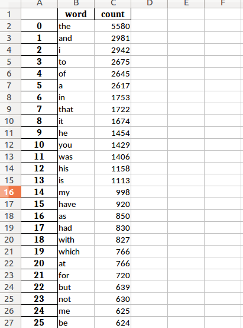

- **append()**와 **extend()**의 비교

```python
x = ['Google', 'Facebook', 'Twitter']
y = ['Instagram', 'TikTok']
x.append(y)
print('Appended x:', x)
```

```
## Appended x: ['Google', 'Facebook', 'Twitter', ['Instagram', 'TikTok']]
```

```python
x = ['Google', 'Facebook', 'Twitter']
y = ['Instagram', 'TikTok']
x.extend(y)
print('Extended x:', x)
```

```
## Extended x: ['Google', 'Facebook', 'Twitter', 'Instagram', 'TikTok']
```

1. 1-2, 6-7행: *x*와 *y*에 리스트 [‘Google’, ‘Facebook’, ‘Twitter’]와 리스트 [‘Instagram’, ‘TikTok’]를 각각 저장한다.
2. 3행: *x*에 *y*를 덧붙인다(append).
3. 4행: 이 *x*를 출력한다. 기존 리스트 *x*에 리스트 *y*가 리스트 구조 그대로 추가되어 있다.
4. 8행: *x*에 *y*를 추가하여 확장한다(extend).
5. 9행: 이 *x*를 출력한다. 기존 리스트 *x*에 리스트 *y*의 원소들이 추가되어 있다. 즉 리스트 구조가 아닌 리스트의 원소들이 *x*에 추가된다.

```python
freq_df[:10]
```

```
##    word  count
## 0   the   5580
## 1   and   2981
## 2     i   2942
## 3    to   2675
## 4    of   2645
## 5     a   2617
## 6    in   1753
## 7  that   1722
## 8    it   1674
## 9    he   1454
```

1. 1행: *freq_df*를 10행까지만 출력한다.

#### 4. 데이터프레임 형식으로 저장된 csv 파일을 읽어와서 단어 빈도 목록 만들기

```python
import pandas as pd

sherlock_df = pd.read_csv('result/sherlock_holmes_updated.csv')
sherlock_df
```

```
##   chapter_num  ...                                               body
## 0           I  ...  To Sherlock Holmes she is always the woman. I ...
## 1           I  ...  At three o’clock precisely I was at Baker Stre...
## 2           I  ...  I slept at Baker Street that night, and we wer...
##
## [3 rows x 4 columns]
```

1. 3행: sherlock_holmes_updated.csv 파일을 **pd.read_csv()** 함수로 읽어 *sherlock_df*에 저장한다.
2. 4행: *sherlock_df*를 3행까지만 출력한다. 총 4개의 칼럼으로 구성되어 있고 각 칼럼은 챕터 번호(chapter_num), 챕터 제목(chapter_title), 소챕터(small_chapter), 소챕터의 내용(body)으로 되어 있다.

```python
sherlock_body = sherlock_df['body'].to_list()
len(sherlock_body)
```

```
## 3
```

```python
from collections import Counter

word_lists = []
for body in sherlock_body:
    bdy = body.lower()
    bdy = re.sub(pattern='[\.\!\?,\'\"“”]', repl='', string=bdy)
    # bdy_splitted = bdy.split(' ')
    bdy_splitted = re.split(' |<p>', bdy)
    word_lists.extend(bdy_splitted)

words_freqs = Counter(word_lists)

for itm in list(words_freqs.items())[:10]:
    print(itm)
```

```
## ('to', 245)
## ('sherlock', 11)
## ('holmes', 46)
## ('she', 71)
## ('is', 86)
## ('always', 5)
## ('the', 444)
## ('woman', 11)
## ('i', 256)
## ('have', 62)
```

```python
freqs_per_chapter = []
for i, row in sherlock_df.iterrows():
    bdy = row['body'].lower()
    bdy = re.sub(pattern='[\.\!\?,\'\"“”]', repl='', string=bdy)
    # bdy_splitted = bdy.split(' ')
    bdy_splitted = re.split(' |<p>', bdy)
    freq = Counter(bdy_splitted)
    freqs_per_chapter.append(freq)

len(freqs_per_chapter)
```

```
## 3
```

```python
list(freqs_per_chapter[0].items())[:10]
```

```
## [('to', 92), ('sherlock', 1), ('holmes', 24), ('she', 17), ('is', 37), ('always', 3), ('the', 151), ('woman', 4), ('i', 91), ('have', 32)]
```